| title: **“Recognition of quality of exercises based on Weight Lifting Exercises data”** |
| --- |
| author: “AShulga” |
| date: “August 17, 2015” |

### Synopsys

```r
## General
Sys.setlocale("LC_ALL", "english")
require(ggplot2); require (caret)
require(randomForest); require(kernlab); require(gbm)
set.seed(12344321) ## for replicability
```

```r
## Load the data
if (!exists("trainData") || !exists("testData")) {
        if (length(grep("pml-training.csv", dir())) <= 0) {
                download.file(url = "https://d396qusza40orc.cloudfront.net/predmachlearn/pml-training.csv", destfile = "pml-training.csv")
        }
        if (length(grep("pml-testing.csv", dir())) <= 0) {
                download.file(url = "https://d396qusza40orc.cloudfront.net/predmachlearn/pml-testing.csv", destfile = "pml-testing.csv")
        }
        trainData <- read.csv("pml-training.csv", header = TRUE)
        testData <- read.csv("pml-testing.csv", header = TRUE)
}
```

### Data preparation and analysis

The dataset consists of 159 predictors representing data generated by 4 sensors across different parameters. Standard range of statistics is calculated for sensor data. Our strategy is to get rid of predictors that contain little relevant information (have little varience or too many NAs in the data) or are highly correlated. We would also ignore timestamps in our analysis.

```r
## find and remove Near Zero Varience predictors
trainDS <- trainData[,-nearZeroVar(trainData)]

## remove timestamps and other data that contains poor signal (too many NAs)
trainDS <- trainDS[,-c(1,3:6)]
trainDS <- trainDS[,-which(apply(is.na(trainDS),2,function(x) {sum(x)/length(x)})>0.95)]

## find and remove predictors which are highly correlated (90% correlation)
highCorr <- findCorrelation(cor(trainDS[,-c(1,ncol(trainDS))]), 0.90)
trainDS <- trainDS[,-(highCorr+1)]

ncol(trainDS)-1 ## show remaining number of predictors
```

```
## [1] 46
```

```r
## The following code is for additional validation test
##train_index <- createDataPartition(trainDS$classe, p = 0.90, list = FALSE)
##trainDS <- trainDS[train_index,]
##testDS <- trainDS[-train_index,]
```

As we can see only 46 predictors are left for our analysis. The figure below demonstrates that the correlation betwean remaining predictors is moderate.

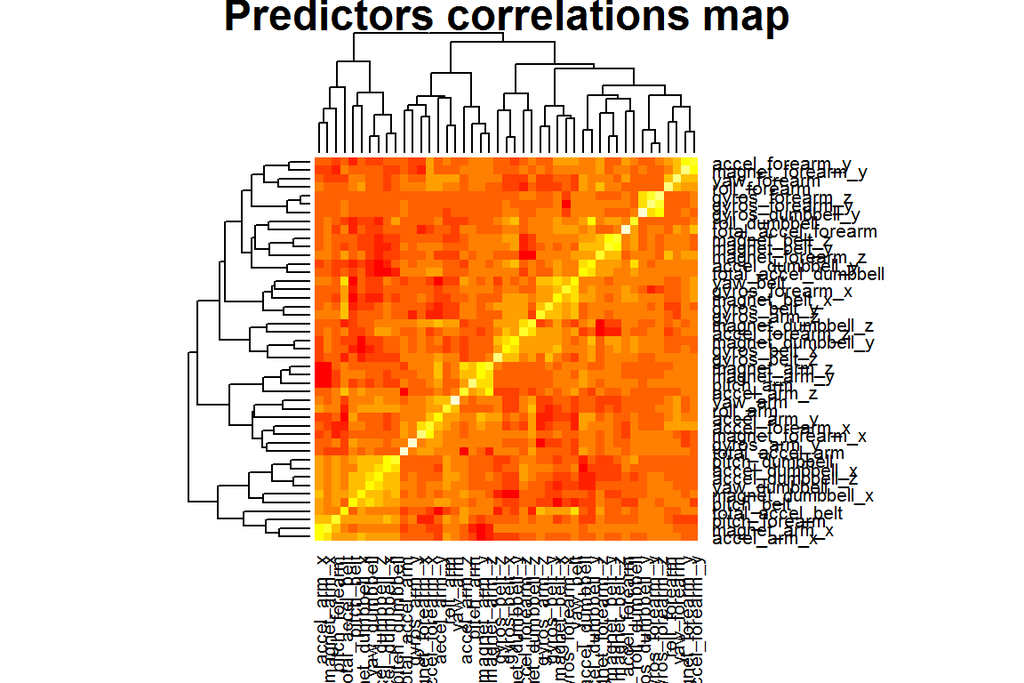

```r
heatmap(cor(trainDS[,-c(1,ncol(trainDS))]), main = "Predictors correlations map")
```

### Model development

Our strategy is to build 3 types of models and then create an ensamble that will produce final predictions via majority vote method. Each model will be tuned based on 10-folds cross-validation.

Our first model is Boosted trees model tuned with predictors interaction up to 6 and number of trees up to 200.

```r
gbmGrid <- expand.grid(interaction.depth = c(1,3)*2, n.trees = c(1, 4, 8)*25, shrinkage = .1, n.minobsinnode = 10)
bootControl = trainControl(method = "cv", number = 10)
set.seed(135) ## to compare iterations
fitGBM <- train(classe ~ ., data = trainDS, method="gbm", trControl = bootControl, verbose = FALSE, tuneGrid = gbmGrid)
fitGBM
```

```
## Stochastic Gradient Boosting
##
## 19622 samples
##    46 predictor
##     5 classes: 'A', 'B', 'C', 'D', 'E'
##
## No pre-processing
## Resampling: Cross-Validated (10 fold)
## Summary of sample sizes: 17659, 17662, 17659, 17660, 17659, 17661, ...
## Resampling results across tuning parameters:
##
##   interaction.depth  n.trees  Accuracy   Kappa      Accuracy SD
##   2                   25      0.7783117  0.7189918  0.013787559
##   2                  100      0.9055654  0.8804844  0.008254918
##   2                  200      0.9461323  0.9318399  0.006639655
##   6                   25      0.9062789  0.8813122  0.006792473
##   6                  100      0.9770155  0.9709219  0.004801254
##   6                  200      0.9913367  0.9890420  0.002758651
##   Kappa SD
##   0.017448388
##   0.010446269
##   0.008408184
##   0.008594206
##   0.006076240
##   0.003489642
##
## Tuning parameter 'shrinkage' was held constant at a value of 0.1
##
## Tuning parameter 'n.minobsinnode' was held constant at a value of 10
## Accuracy was used to select the optimal model using  the largest value.
## The final values used for the model were n.trees = 200,
##  interaction.depth = 6, shrinkage = 0.1 and n.minobsinnode = 10.
```

```r
##plot(fitGBM)
##confusionMatrix(predict(fitGBM, testDS), testDS$classe)
```

Our second model is Support Vector Machines model used on PCA preprocessed data.

```r
bootControl = trainControl(method = "cv", number = 10)
set.seed(135) ## to compare iterations
fitSVM <- train(classe ~ ., data = trainDS, method="svmRadial", preProcess = ("pca"), PCAthresh = 0.9, tuneLength = 3, trControl = bootControl, scaled = FALSE)
fitSVM
```

```
## Support Vector Machines with Radial Basis Function Kernel
##
## 19622 samples
##    46 predictor
##     5 classes: 'A', 'B', 'C', 'D', 'E'
##
## Pre-processing: principal component signal extraction, scaled, centered
## Resampling: Cross-Validated (10 fold)
## Summary of sample sizes: 17659, 17662, 17659, 17660, 17659, 17661, ...
## Resampling results across tuning parameters:
##
##   C     Accuracy   Kappa      Accuracy SD  Kappa SD
##   0.25  0.8795232  0.8473188  0.005919380  0.007544193
##   0.50  0.9076547  0.8829498  0.004938640  0.006270583
##   1.00  0.9384365  0.9220058  0.002907627  0.003686076
##
## Tuning parameter 'sigma' was held constant at a value of 0.0259184
## Accuracy was used to select the optimal model using  the largest value.
## The final values used for the model were sigma = 0.0259184 and C = 1.
```

```r
##confusionMatrix(predict(fitSVM, testDS), testDS$classe)
```

Our third model is Random Forests model with number of trees up to 100 and tuned over randomly selected predictors.

```r
rfGrid <- expand.grid(mtry = c(1,3,6,9,12))
bootControl = trainControl(method = "cv", number = 10)
set.seed(135) ## to compare iterations
fitRF <- train(classe ~ ., data = trainDS, method="rf", trControl = bootControl, ntree = 100, tuneGrid = rfGrid)
fitRF
```

```
## Random Forest
##
## 19622 samples
##    46 predictor
##     5 classes: 'A', 'B', 'C', 'D', 'E'
##
## No pre-processing
## Resampling: Cross-Validated (10 fold)
## Summary of sample sizes: 17659, 17662, 17659, 17660, 17659, 17661, ...
## Resampling results across tuning parameters:
##
##   mtry  Accuracy   Kappa      Accuracy SD  Kappa SD
##    1    0.9663648  0.9573996  0.002701563  0.003426106
##    3    0.9946491  0.9932313  0.001752318  0.002216846
##    6    0.9962290  0.9952300  0.001541356  0.001949720
##    9    0.9960252  0.9949722  0.001310587  0.001657785
##   12    0.9960251  0.9949721  0.001416963  0.001792271
##
## Accuracy was used to select the optimal model using  the largest value.
## The final value used for the model was mtry = 6.
```

```r
##confusionMatrix(predict(fitRF, testDS), testDS$classe)
```

Below is out-of-sample Accuracy estimates for each of the model developed. Accuracy is measured across same cross-validation data folds for each of the models so it can be compared between the models.

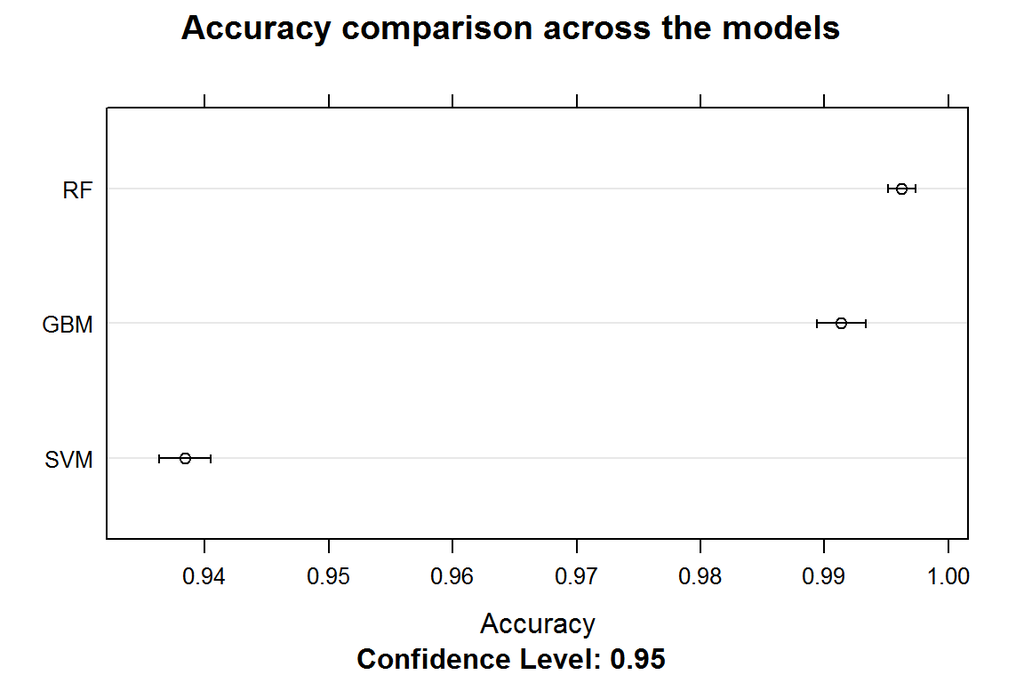

```r
resamps <- resamples(list(RF = fitRF, GBM = fitGBM, SVM = fitSVM))
trellis.par.set(caretTheme())
dotplot(resamps, metric = "Accuracy", main = "Accuracy comparison across the models")
```

As we can see all three models have comparably high Accuracy (out-of-sample estimate is in the range of 93.5-99.6%) with Random Forest demonstrating the highest result (99.6%).

### Development of ensemble model

Our ensamble model will be based on bagging method with each of the 3 models voting for prediction result. Final prediction will be based on majority vote method.

```r
models <- list(GBM = fitGBM, SVM = fitSVM, RF = fitRF)
result <- predict(models, testData)
result <- as.data.frame(result)
t_vote <- numeric(5)
votes <- apply(result,1,function(x) {
        for (i in 1:5) t_vote[i] <- sum((x == LETTERS[i])*1)
        LETTERS[which(t_vote == max(t_vote))]
})
##confusionMatrix(as.factor(votes),testDS$classe) ## used for validation
votes
```

```
##  [1] "B" "A" "B" "A" "A" "E" "D" "B" "A" "A" "B" "C" "B" "A" "E" "E" "A"
## [18] "B" "B" "B"
```

Above is a printout of test set predictions to be submitted to Coursera.

### Creation of files with answers for submission

According to our assignment below is the code for creation of files with the test dataset predictions to be submitted to Coursera.

```r
if (!dir.exists("test_answers")) dir.create("test_answers")
setwd("test_answers")
for(i in 1:length(votes)){
    filename = paste0("problem_id_",i,".txt")
    write.table(votes[i],file=filename,quote=FALSE,row.names=FALSE,col.names=FALSE)
}
setwd("..")
```